# Big_Data_Query_Analysis

### Big Data Set Query & Analysis - Caleb Wilkins 11/15/2021

```python
# imports
%matplotlib inline
import numpy as np
import matplotlib
import matplotlib.pyplot as plt
import scipy
from scipy import stats
import pickle
plt.rcParams["figure.figsize"] = (10,8)
plt.rcParams['pcolor.shading'] = 'auto';
```

This notebook contains a more "scientific report" style walkthrough of real world data from the famous LHC particle accelerator that I was granted access to by UW Professor Morales, who supervised my research. An in depth background of the field of study is given alongside the analysis of the data I am working with.

The Large Hadron Collider (LHC) is a multinational particle accelerator located in France and Switzerland. A hadron is a subatomic particle made of multiple quarks bound by the strong nuclear force. While there are several detectors at the LHC, of interest for these labs is ATLAS, which was conceived in 1992 and became operational in 2008. One of the main goals for the creation of ATLAS was to either confirm or deny the existance of the Higgs boson, which is a missing piece of the puzzle in the standard model theory of particle physics. The Higgs boson was first theorized to exist in 1964 and was proposed to give the W and Z gauge bosons mass, both of which are particles which had previously been predicted to be massless. The tricky part in detecting the Higgs boson is related to its mass. It has been deduced to be incredibly massive relative to other subatomic particles, and it has a very short halflife.

The data we are working with is derived from proton-proton collisions. Higgs bosons from this collision should decay into a bottom quark-antiquark pair, two bosons, and two photons. It's not quite that simple, though, since there can be a whole host of produced particles and decays in the collision as well. To model this, we are given two sets of data, one that represents the Higgs data and one from quantum chromodynamic (QCD) contamination from strong interactions between quarks and gluons.

First we will define the variables in the data. These come from Table 1 (pp.17) of *"Identification of boosted Higgs bosons decaying into b-quark pairs with the ATLAS detector at 13 TeV"* (The ATLAS Collaboration).

```python
# Loading in the data
qcd = pickle.load(open("./qcd_100000_pt_1000_1200.pkl", 'rb'))
higgs = pickle.load(open("./higgs_100000_pt_1000_1200.pkl",'rb'))
```

| Variable | Symbol | Definition | Equation | Description |
| --- | --- | --- | --- | --- |
| pt | $p_t$ | Transverse Momentum | $\sqrt{p_x^2 + p_y^2}$ | Transverse in reference to the xy-plane, which is perpendicular to the beam line of the particles |
| eta | $\eta$ | Pseudorapidity | $-\ln(\tan(\frac{\theta}{2}))$ | Angle of the particle relative to the beam axis |
| phi | $\phi$ | Azimuthal Angle | $\cos^{-1}\frac{x}{r}$ | Angle above x-axis |
| mass | $m$ | (Rest) Mass | $E^2=p^2+m^2$ |  |
| ee2 | $E_2$ | 2-Point ECF Ratio | $\sum_{i<j\in J}p_{T,i}p_{T,j}\Delta R_{ij}\frac{1}{p_{T,J}^2}$ | ECF = Energy Correlation Function |
| ee3 | $E_3$ | 3-Point ECF Ratio | $\sum_{i<j<k\in J}p_{T,i}p_{T,j}p_{T,k}\Delta R_{ij}\Delta R_{jk}\Delta R_{jk}\frac{1}{p_{T,J}^3}$ |  |
| d2 | $D_2$ | 3-to-2 Point ECF Ratio | $\frac{e_3}{e_2^3}$ |  |
| angularity | $a_3$ | Angularity | $\frac{1}{m_J}\sum_{i\in J}E_i\sin^{-2}(\theta_i)\cos^3(\theta_i)$ |  |

The variables listed above are the key variables needed for analyzing the data. Our goal is to inspect each of the variables by making histograms of each, along with semi-log plots to better observe the behaviors of their distributions. Our two data sets (QCD & Higgs) both contain 14 columns and 100,000 rows, so our first step in analyzing them will be to write a function that will allow us to visualize each variable with more ease.

```python
# The following function's purpose is to create 4 separate plots that each focus on
# one specified variable. The upper left plot will show the data on the variable from
# the Higgs data set. The upper right plot will show a semi-log visualization of the
# data on the variable from the Higgs data set. The lower left plot will show the data
# on the variable from the QCD data set. The lower right plot will show a semi-log
# visualization of the data on the variable from the QCD data set.

# The arguments the function takes are as follows:
# 'var' is the variable of interest that will be plotted (called by the name as it exists in the data sets)
# 'name' is the accepted name of the variable as we wish it to be presented in the title of the plots
# 'units' is the specified unit measure of the variable being plotted, named as we wish it to be presented in the labels of the plot

def histograms(var, name, units):
    plt.rcParams["figure.figsize"] = (40,50)
    fig, ax = plt.subplots(2, 2)
    higgs_hist = ax[0, 0]
    higgs_log = ax[0, 1]
    qcd_hist = ax[1, 0]
    qcd_log = ax[1, 1]


    a = higgs_hist.hist(higgs.get(var), density = True, bins = 50, alpha = 0.6)
    higgs_hist.set_title(name + ' in Higgs Data Set')
    higgs_hist.set_xlabel(name + units)
    higgs_hist.set_ylabel('Frequency')

    b = higgs_log.hist(higgs.get(var), density = True, bins = 50, alpha = 0.8)
    higgs_log.set_title('Log of ' + name + ' in Higgs Data Set')
    higgs_log.set_yscale('log')
    higgs_log.set_xlabel(name + units)
    higgs_log.set_ylabel('log(Frequency)')

    c = qcd_hist.hist(qcd.get(var), density = True, bins = 50, color = 'g', alpha = 0.6)
    qcd_hist.set_title(name + ' in QCD Data Set')
    qcd_hist.set_xlabel(name + units)
    qcd_hist.set_ylabel('Frequency')

    d = qcd_log.hist(qcd.get(var), density = True, bins = 50, color = 'g', alpha = 0.8)
    qcd_log.set_title('Log of ' + name + ' in QCD Data Set')
    qcd_log.set_yscale('log')
    qcd_log.set_xlabel(name + units)
    qcd_log.set_ylabel('log(Frequency)')

    for plot in [higgs_hist, higgs_log, qcd_hist, qcd_log]:
        plot.title.set_fontsize(48)
        for item in ([plot.xaxis.label, plot.yaxis.label] + plot.get_xticklabels() + plot.get_yticklabels()):
            item.set_fontsize(36)
```

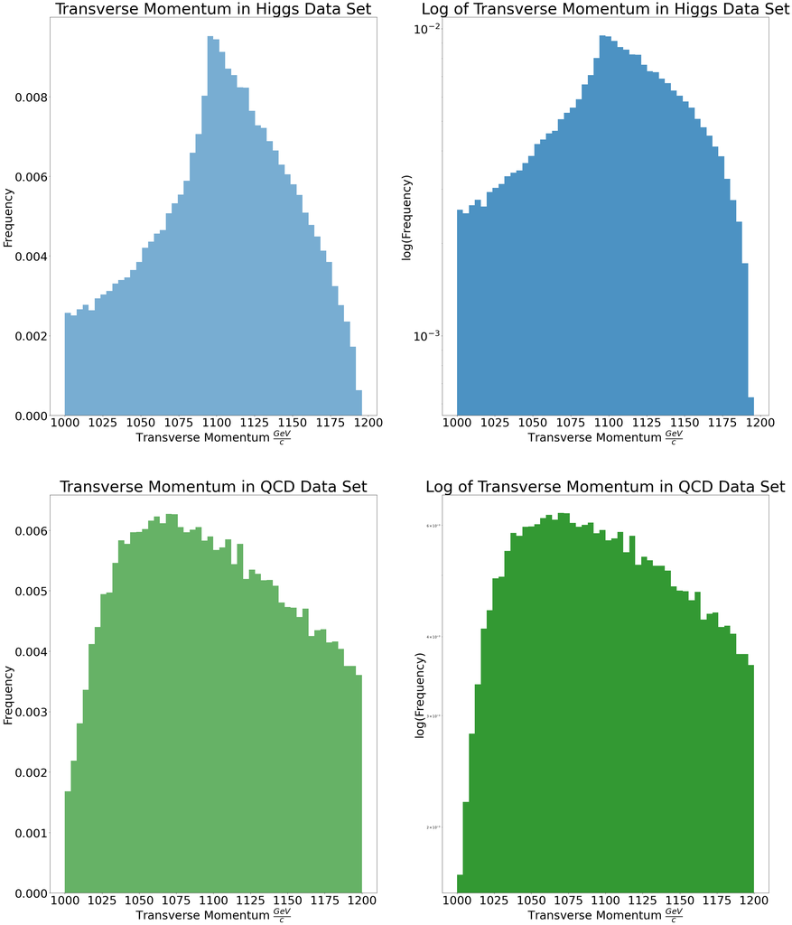

```python
histograms('pt', 'Transverse Momentum', r' $\frac{GeV}{c}$')
```

The data range I am inspecting is only a subset of the whole (or else it would take a machine with much more processing power than my own to generate these plots). The subsets of the LHC data are divided by the transverse momentum of the observed particles. The data set I am working with spans the 1000-1200 $\frac{GeV}{c}$ range. In this region, the Higgs distribution seems to increase exponentially before peaking at around 1100 $\frac{GeV}{c}$. The QDC distribution on the other hand looks like it could be discretely distributed in this region (perhaps Poisson or Rayleigh). To check the accuracy of this, I will create the corrosponding Poisson and Rayleigh distributions and calculate the $R^2$ value for each. An $R^2$ test is a fitness measurement defined as $1 - \frac{SSR}{SST}$ where SSR is the squared sum of the residuals (the actual minus expected value at that point, squared) and SST is the squared sum of total (the average value of the distribution minus the value at each point, squared). The purpose of the test is to provide how accurate it is that an experimental distribution can be approximated as a distribution of known behavior (such as famous exmaples like a Gaussian, Poisson, or Raleigh distribution). The test results in a numerical value, and the closer this value is to 1.0, the better the approximation is.

```python
# The purpose of the below function is to perform an R-squared test on
# our experimental data from the LHC that compares it to a distribution
# of known behavior, which will help with our further analysis

# The arguments it takes are defined as follows:
# 'y_expected' is the theoretically (mathematically) expected value of a measurement
# 'y_actual' is the experimentally determined measurement
# Both are used in the calculation of the R-squared test, according to the formula
# as explained in the markdown cell above

def r_squared(y_expected, y_actual):
    y_bar = sum(y_actual) / y_actual.size
    ss_tot = sum((y_actual - y_bar)**2)
    ss_res = sum((y_actual - y_expected)**2)
    return 1 - (ss_res / ss_tot)
```

```
R-Squared Poisson:  0.813956551644605
R-Squared Rayleigh:  -1.9621461458645442
```

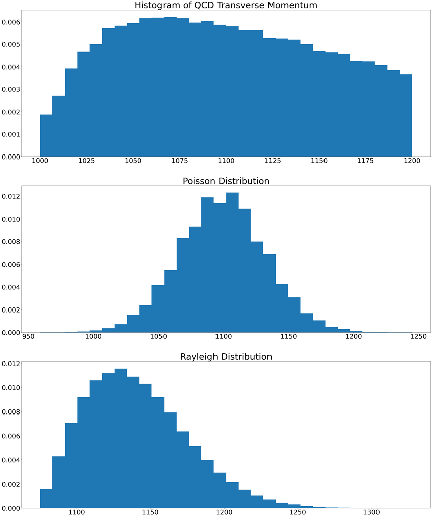

```python
# The following block of code utilizes the R-squared function above to
# test whether our experimental data could be better approximated as
# a Poisson distribution or Raleigh distribution. We will also plot our
# data alongside Poisson and Raleigh distributions of the same mean as our
# data, in order to visually observe which better approximates our data.

mu = np.mean(qcd.get('pt'))
poisson = stats.poisson.rvs(mu, size=qcd.get('pt').size)

sigma = np.std(qcd.get('pt'))
rayleigh = stats.rayleigh.rvs(loc=1075, scale=sigma, size = qcd.get('pt').size)

fig, ax = plt.subplots(3, 1)
ax[0].set_title('Histogram of QCD Transverse Momentum')
histActual = ax[0].hist(qcd.get('pt'), density = True, bins = 30)
ax[1].set_title('Poisson Distribution')
histPoisson = ax[1].hist(poisson, density=True, bins = 30)
ax[2].set_title('Rayleigh Distribution')
histRayleigh = ax[2].hist(rayleigh, density = True, bins = 30)

for plot in [ax[0], ax[1], ax[2]]:
    plot.title.set_fontsize(48)
    for item in ([plot.xaxis.label, plot.yaxis.label] + plot.get_xticklabels() + plot.get_yticklabels()):
        item.set_fontsize(36)

print('R-Squared Poisson: ', r_squared(histPoisson[1], histActual[1]))
print('R-Squared Rayleigh: ', r_squared(histRayleigh[1], histActual[1]))
```

As we can see from the values obtained for $R^2$, the Poisson distribution approximates the QDC distribution better than the Rayleigh (as its $R^2$ value is close to 1).

Next, we will analyze the rest mass distributions for our data range.

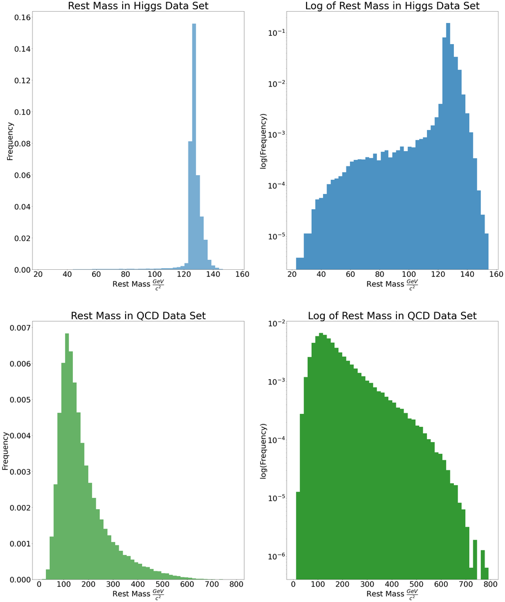

```python
histograms('mass', 'Rest Mass', r' $\frac{GeV}{c^2}$')
```

```
R-Squared Poisson:  -0.6518986548172241
R-Squared Rayleigh:  0.606470523513074
```

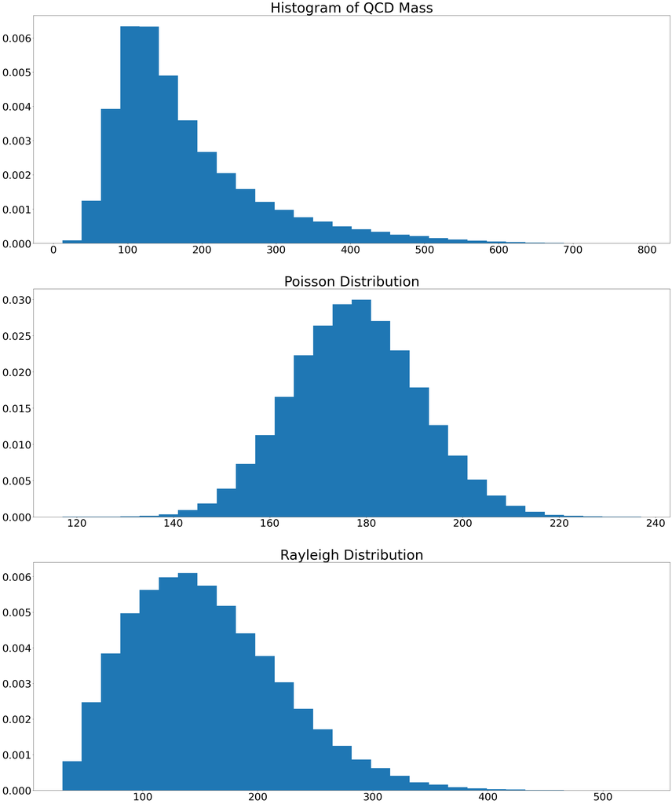

```python
# Just as before, we will use the R-squared test function we wrote in order to
# test which known distribution better approximates our data.

mu = np.mean(qcd.get('mass'))
poisson = stats.poisson.rvs(mu, size=qcd.get('mass').size)

sigma = np.std(qcd.get('mass'))
rayleigh = stats.rayleigh.rvs(loc=30, scale=sigma, size = qcd.get('mass').size)

fig, ax = plt.subplots(3, 1)
ax[0].set_title('Histogram of QCD Mass')
histActual = ax[0].hist(qcd.get('mass'), density = True, bins = 30)
ax[1].set_title('Poisson Distribution')
histPoisson = ax[1].hist(poisson, density=True, bins = 30)
ax[2].set_title('Rayleigh Distribution')
histRayleigh = ax[2].hist(rayleigh, density = True, bins = 30)

for plot in [ax[0], ax[1], ax[2]]:
    plot.title.set_fontsize(48)
    for item in ([plot.xaxis.label, plot.yaxis.label] + plot.get_xticklabels() + plot.get_yticklabels()):
        item.set_fontsize(36)

print('R-Squared Poisson: ', r_squared(histPoisson[1], histActual[1]))
print('R-Squared Rayleigh: ', r_squared(histRayleigh[1], histActual[1]))
```

We see that the Rayleigh distribution does a better job at approximating the QDC distribution than the Poisson in this case, but still not a great job by any means. Regardless of the exact distribution, the background does have a significant presence in the region of the distribution where the peak of the Higgs distribution lies, which will add difficulty in filtering out the background.

The last variable which shows a significant difference between the two distributions is the 2-point ECF ratio:

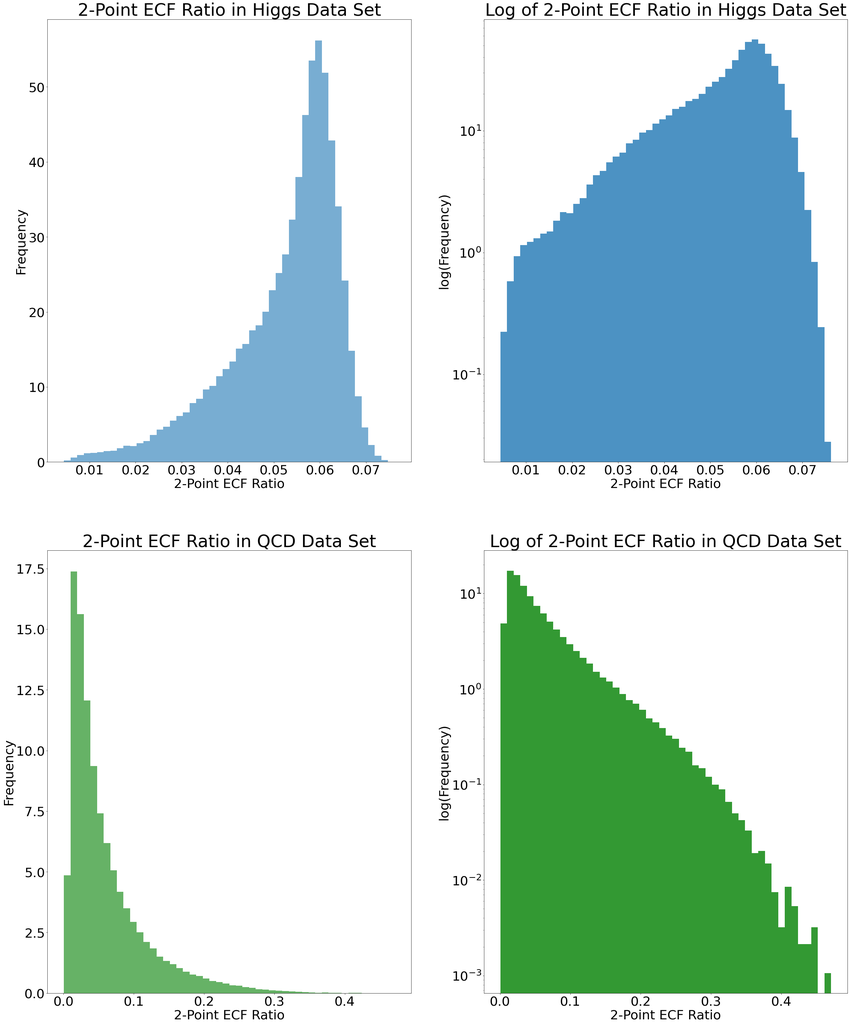

```python
histograms('ee2','2-Point ECF Ratio','')
```

To simplify, the ECF is a measurement of how much of the energy of a collection of particles is in the same general direction. The 2-Point ECF distribution in the Higgs data peaks at 0.06, but there also looks like there could be a very slight other peak at 0.01, as we can see an inflection point there. The QDC distribution peaks very early and then drops off rapidly, a potential mark of an exponential distribution. Though since it is related to randomized vectors, it would make sense that this distribution would be Rayleigh, but to be sure we will check the $R^2$ values of each model distribution just in case.

```
R-Squared Expon:  -724886.1311940665
R-Squared Rayleigh:  0.27043724735952424
```

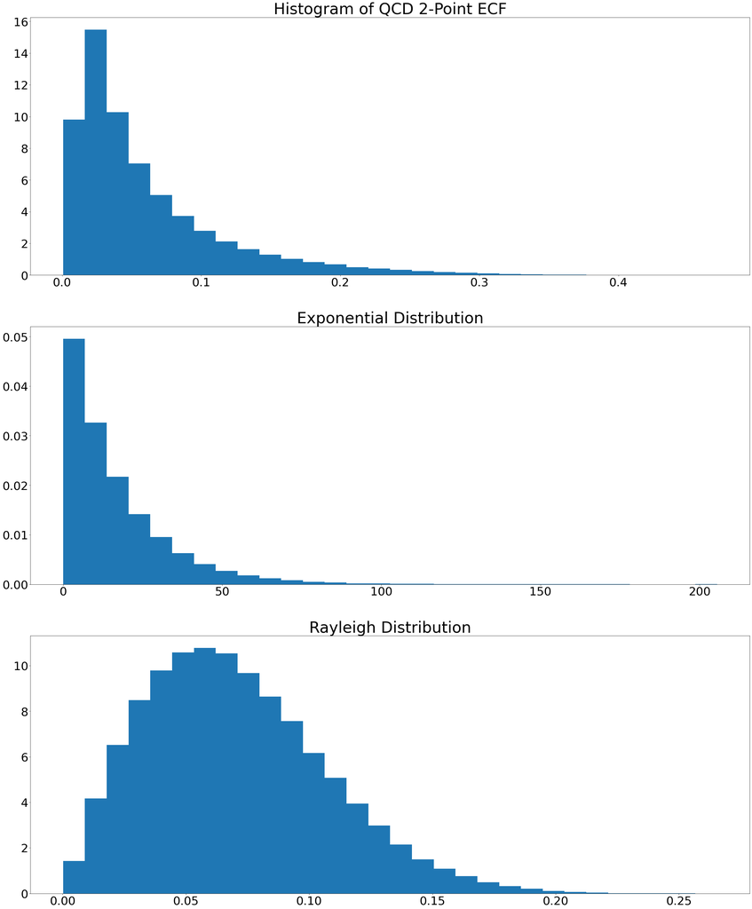

```python
mu = np.mean(qcd.get('ee2'))
lamb = 1 / mu
exp = stats.expon.rvs(scale=lamb, size=qcd.get('mass').size)

sigma = np.std(qcd.get('ee2'))
rayleigh = stats.rayleigh.rvs(loc=0, scale=sigma, size = qcd.get('mass').size)

fig, ax = plt.subplots(3, 1)
ax[0].set_title('Histogram of QCD 2-Point ECF')
histActual = ax[0].hist(qcd.get('ee2'), density = True, bins = 30)
ax[1].set_title('Exponential Distribution')
histExp = ax[1].hist(exp, density=True, bins = 30)
ax[2].set_title('Rayleigh Distribution')
histRayleigh = ax[2].hist(rayleigh, density = True, bins = 30)

for plot in [ax[0], ax[1], ax[2]]:
    plot.title.set_fontsize(48)
    for item in ([plot.xaxis.label, plot.yaxis.label] + plot.get_xticklabels() + plot.get_yticklabels()):
        item.set_fontsize(36)

print('R-Squared Expon: ', r_squared(histExp[1], histActual[1]))
print('R-Squared Rayleigh: ', r_squared(histRayleigh[1], histActual[1]))
```

In this case, neither can really be said to be "good" approximations of the distribution, but we can obviously see the exponential case is completely off the table.

We have thus analyzed some of the most important variables in the search for the Higgs boson, but in order to move forward with the search, we would need to define a more precise criteria for what constitutes "high" transverse momentum.